# The Iteration Loop — building charts by talking to an LLM

**The question.** On a single day, are trips spread evenly across Spain's provinces, or concentrated in a few big ones? By *trip* we mean one person moving from an origin district to a destination district that day — everyday mobility across all modes of transport, not a single kind of vehicle.

**Why it's worth asking.** Whether mobility is even or concentrated tells you where demand — and the case for investment — actually sits. It's the kind of question a single well-chosen chart can answer at a glance.

**The data.** One synthetic day of province-to-province flows: a small, shareable stand-in for the real national file (same columns, illustrative volumes). Each row is the estimated number of trips from one origin district to one destination district; the first two digits of the origin code are its province. Those counts are population-reweighted estimates, so they arrive as decimals rather than whole people.

This notebook is a **worked example of the iteration loop**. We never hand-write the final chart. We describe what we want, the model writes the code, we run it, look at what came back, and describe the next change — *generate → look → name the gap → ask again* — until both charts answer the question.

## 1. Start from the question — ask which chart fits

Before any plotting code, describe the data and the question to the model and ask which chart types would show concentration. A possible prompt is as follows:

```
I have a mobility dataset and want to analyze whether trips on a given day are spread evenly across Spain’s provinces or concentrated in a few large provinces.

The dataset is available here:
https://raw.githubusercontent.com/pmarcelino/mobillity-courses/main/mobillity-univ/module-4-visualizing/data/main/mobillity-univ/module-4-visualizing/data/mitma-spain-od-synthetic/province_flows_practice.csv

Suggest suitable chart types for this analysis.

For each chart type, briefly explain:

1. What question it helps answer.
2. What variables from the dataset it would likely use.
3. Why it is useful for identifying whether trips are evenly distributed or concentrated.
```

And a possible answer is as follows:

```
I'll take a look at the actual dataset first so my chart suggestions match its real structure. Good — I can see the structure. Four columns: `fecha` (date, all `20250303` here, i.e. a single day), `origen` and `destino` (5-digit location codes), and `viajes` (trip counts, e.g. `725.035`).

One thing that shapes every chart below: the province isn't a column on its own. In Spain's INE coding, the province is the **first two digits** of the `origen`/`destino` codes (01 = Álava, 08 = Barcelona, 28 = Madrid, …, 52 = Melilla). So the prep step is to extract that 2-digit prefix and sum `viajes` per province. You also need to decide *which* province you mean — origin province, destination province, or both — since a trip has two endpoints. For "are trips concentrated," aggregating by origin and by destination separately (then comparing) is usually the most informative.

You can already smell concentration in the raw rows: Madrid (28…) and Barcelona (08…) flows sit in the thousands while most others are in the hundreds.

Here are the chart types I'd suggest, strongest first.

**1. Ranked bar chart (ideally a Pareto chart)**
- *Question:* Which provinces carry the most trips, and how steep is the fall-off from the top ones?
- *Variables:* province (2-digit prefix of `origen` or `destino`) on the x-axis, summed `viajes` on the y-axis, bars sorted descending. Add a cumulative-percentage line on a secondary axis to make it a proper Pareto chart.
- *Why it fits:* the *shape* answers the question directly. A steep drop then a long flat tail = concentration; a gently sloping, near-flat profile = even distribution. The cumulative line quantifies it ("the top 3 provinces account for X% of all trips").

**2. Lorenz curve (with a Gini coefficient)**
- *Question:* How unequal is the trip distribution across provinces, as a single comparable number?
- *Variables:* cumulative share of provinces (x) vs. cumulative share of `viajes` (y), after sorting provinces from fewest to most trips.
- *Why it fits:* this is the purpose-built tool for concentration. Perfect evenness lies on the 45° diagonal; the more the curve bows below it, the more concentrated the trips. The Gini coefficient (area between curve and diagonal) collapses that into one 0–1 number, which is ideal if you later want to compare days, or origins vs. destinations.

**3. Choropleth map**
- *Question:* *Where* is the concentration — is it spatial (a few big urban provinces) or scattered?
- *Variables:* province polygons (joined on the 2-digit code) shaded by summed `viajes`.
- *Why it fits:* the ranked chart tells you concentration exists; the map tells you it's Madrid/Barcelona/Valencia rather than a random set. For a mobility dataset the geographic pattern is often the actual insight, and dark clusters vs. a pale background make even-vs-concentrated visually obvious.

**4. Treemap**
- *Question:* What fraction of the whole does each province represent?
- *Variables:* one rectangle per province, area proportional to summed `viajes`.
- *Why it fits:* it's an intuitive part-to-whole view. A few dominant rectangles swallowing the canvas reads instantly as concentration; many similarly-sized tiles reads as even. Good for a non-technical audience where a Lorenz curve wouldn't land.

**5. Histogram of per-province trip totals** (secondary/supporting)
- *Question:* What does the distribution of province-level totals look like?
- *Variables:* summed `viajes` per province, binned into a frequency histogram.
- *Why it fits:* a strong right-skew (many low-trip provinces, a few extreme high-trip ones) is the signature of concentration; a roughly symmetric, tight distribution suggests evenness. Caveat: with only ~52 provinces the bins are coarse, so treat this as corroboration for the Lorenz/Pareto view rather than the headline chart.

If I were choosing two, I'd pair the **Pareto chart** (immediate, readable) with the **Lorenz curve + Gini** (rigorous and comparable), and add the **choropleth** whenever the geography matters.

Want me to actually run this on the file — aggregate by province and generate, say, the Pareto chart and Lorenz curve with a computed Gini — so you can see how concentrated this particular day is?
```

Let's assume that for this case we will use the ranked bar chart and the choropleth map.

## 2. First chart, first draft — a bar of the busiest provinces

Start with the simpler one, the ranked bar chart. A single prompt does the whole *0 → 1*: read the file, total each province's trips, and draw a bar chart. For that, you can use this prompt in the same conversation:

```
Great. I want to use a Pareto chart and a choropleth map later.

For now, start with a ranked bar chart.

Using the dataset below, write Python code that:

1. Loads the CSV file.
2. Aggregates trips by Spanish province for a selected day.
3. Sorts provinces from highest to lowest number of trips.
4. Produces a ranked bar chart showing which provinces account for the most trips.

Dataset:

https://raw.githubusercontent.com/pmarcelino/mobillity-courses/main/mobillity-univ/module-4-visualizing/data/main/mobillity-univ/module-4-visualizing/data/mitma-spain-od-synthetic/province_flows_practice.csv

The goal is to understand whether trips are spread evenly across provinces or concentrated in a few large ones.

Please include clear, beginner-friendly Python code using pandas and matplotlib.
```

This will result in something like this:

```
Day analysed: 20250303
Provinces with trips: 52
Top 2 provinces account for 29.2% of all trips

province
Madrid         36014.992
Barcelona      32850.010
Valladolid      5052.487
La Rioja        4984.816
Girona          4974.441
Alicante        4754.947
León            4730.292
Araba/Álava     4540.073
Jaén            4325.452
Soria           4302.063
Name: viajes, dtype: float64

Chart saved as province_ranked_bar.png
```

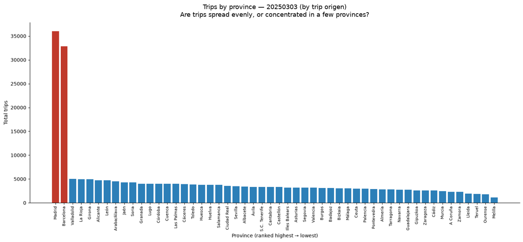

```python
"""
Ranked bar chart: trips by Spanish province for a single day.

Goal: see whether trips are spread evenly across provinces
or concentrated in just a few large ones.

Data: MITMA-style origin-destination flows (synthetic).
Columns: fecha (date), origen (origin code), destino (destination code), viajes (trips).
"""

import pandas as pd
import matplotlib.pyplot as plt

# ---------------------------------------------------------------
# 0. Settings you can change
# ---------------------------------------------------------------
CSV_URL = (
    "https://raw.githubusercontent.com/pmarcelino/mobillity-courses/"
    "main/mobillity-univ/module-4-visualizing/data/"
    "main/mobillity-univ/module-4-visualizing/data/mitma-spain-od-synthetic/province_flows_practice.csv"
)
SELECTED_DAY = 20250303      # the day we want to analyse (YYYYMMDD)
PROVINCE_FROM = "origen"     # aggregate by trip ORIGIN. Change to "destino" for destinations.

# ---------------------------------------------------------------
# 1. Load the CSV
#    IMPORTANT: read the code columns as text (str), otherwise pandas
#    turns "01187" into the number 1187 and we lose the leading zero
#    that tells us the province.
# ---------------------------------------------------------------
df = pd.read_csv(CSV_URL, dtype={"origen": str, "destino": str})

# ---------------------------------------------------------------
# 2. Extract the province code
#    A location code has 5 digits; the FIRST TWO are the province
#    (e.g. 28xxx = Madrid, 08xxx = Barcelona).
#    .str.zfill(5) makes sure every code is 5 characters long.
# ---------------------------------------------------------------
df[PROVINCE_FROM] = df[PROVINCE_FROM].str.zfill(5)
df["province_code"] = df[PROVINCE_FROM].str[:2]

# Map the 2-digit INE code to a readable province name.
PROVINCE_NAMES = {
    "01": "Araba/Álava", "02": "Albacete", "03": "Alicante", "04": "Almería",
    "05": "Ávila", "06": "Badajoz", "07": "Illes Balears", "08": "Barcelona",
    "09": "Burgos", "10": "Cáceres", "11": "Cádiz", "12": "Castellón",
    "13": "Ciudad Real", "14": "Córdoba", "15": "A Coruña", "16": "Cuenca",
    "17": "Girona", "18": "Granada", "19": "Guadalajara", "20": "Gipuzkoa",
    "21": "Huelva", "22": "Huesca", "23": "Jaén", "24": "León",
    "25": "Lleida", "26": "La Rioja", "27": "Lugo", "28": "Madrid",
    "29": "Málaga", "30": "Murcia", "31": "Navarra", "32": "Ourense",
    "33": "Asturias", "34": "Palencia", "35": "Las Palmas", "36": "Pontevedra",
    "37": "Salamanca", "38": "S.C. Tenerife", "39": "Cantabria", "40": "Segovia",
    "41": "Sevilla", "42": "Soria", "43": "Tarragona", "44": "Teruel",
    "45": "Toledo", "46": "Valencia", "47": "Valladolid", "48": "Bizkaia",
    "49": "Zamora", "50": "Zaragoza", "51": "Ceuta", "52": "Melilla",
}
df["province"] = df["province_code"].map(PROVINCE_NAMES)

# ---------------------------------------------------------------
# 3. Keep only the selected day, then add up trips per province
# ---------------------------------------------------------------
day_df = df[df["fecha"] == SELECTED_DAY]

trips_by_province = (
    day_df.groupby("province")["viajes"]
    .sum()
    .sort_values(ascending=False)   # highest number of trips first
)

# A quick text summary (nice for understanding the numbers)
total = trips_by_province.sum()
top2_share = trips_by_province.head(2).sum() / total * 100
print(f"Day analysed: {SELECTED_DAY}")
print(f"Provinces with trips: {len(trips_by_province)}")
print(f"Top 2 provinces account for {top2_share:.1f}% of all trips\n")
print(trips_by_province.head(10))

# ---------------------------------------------------------------
# 4. Draw the ranked bar chart
# ---------------------------------------------------------------
fig, ax = plt.subplots(figsize=(15, 7))

# Colour the two biggest provinces differently so concentration stands out.
colors = ["#c0392b" if i < 2 else "#2c7fb8" for i in range(len(trips_by_province))]

ax.bar(trips_by_province.index, trips_by_province.values, color=colors)

ax.set_title(
    f"Trips by province — {SELECTED_DAY} (by trip {PROVINCE_FROM})\n"
    "Are trips spread evenly, or concentrated in a few provinces?",
    fontsize=13, pad=12,
)
ax.set_xlabel("Province (ranked highest → lowest)")
ax.set_ylabel("Total trips")

# Rotate the province names so they don't overlap.
plt.xticks(rotation=90, fontsize=8)

# Remove the top/right borders for a cleaner look.
ax.spines["top"].set_visible(False)
ax.spines["right"].set_visible(False)

plt.tight_layout()
plt.savefig("province_ranked_bar.png", dpi=150)
print("\nChart saved as province_ranked_bar.png")
```

Not bad for a first draft!

## 3. Refine it with a prompt — and taste

In this case, let's imagine that we don't like the colours and we want a line showing the average trips per province. Let's tell that to the model and see what comes back.

```
Looks good. Now update the ranked bar chart with two changes:

1. Use a red-to-green color gradient for the bars, where provinces with more trips appear closer to red and provinces with fewer trips appear closer to green.
2. Add a horizontal line showing the average number of trips per province.

Please update the Python code accordingly, keeping it beginner-friendly and using pandas and matplotlib.
```

And the answer is:

```
Day analysed: 20250303
Provinces with trips: 52
Top 2 provinces account for 29.2% of all trips

province
Madrid         36014.992
Barcelona      32850.010
Valladolid      5052.487
La Rioja        4984.816
Girona          4974.441
Alicante        4754.947
León            4730.292
Araba/Álava     4540.073
Jaén            4325.452
Soria           4302.063
Name: viajes, dtype: float64

Chart saved as province_ranked_bar.png
```

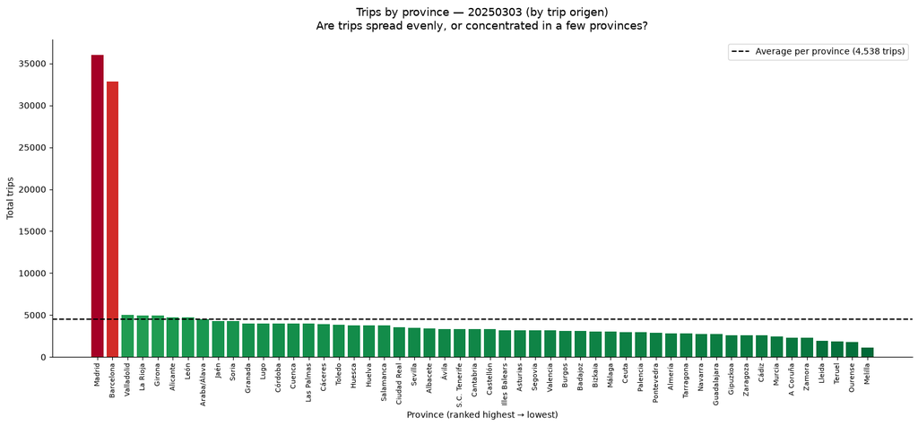

```python
"""
Ranked bar chart: trips by Spanish province for a single day.

Goal: see whether trips are spread evenly across provinces
or concentrated in just a few large ones.

Data: MITMA-style origin-destination flows (synthetic).
Columns: fecha (date), origen (origin code), destino (destination code), viajes (trips).
"""

import pandas as pd
import matplotlib.pyplot as plt
from matplotlib.colors import Normalize

# ---------------------------------------------------------------
# 0. Settings you can change
# ---------------------------------------------------------------
CSV_URL = (
    "https://raw.githubusercontent.com/pmarcelino/mobillity-courses/"
    "main/mobillity-univ/module-4-visualizing/data/"
    "main/mobillity-univ/module-4-visualizing/data/mitma-spain-od-synthetic/province_flows_practice.csv"
)
SELECTED_DAY = 20250303      # the day we want to analyse (YYYYMMDD)
PROVINCE_FROM = "origen"     # aggregate by trip ORIGIN. Change to "destino" for destinations.

# ---------------------------------------------------------------
# 1. Load the CSV
#    IMPORTANT: read the code columns as text (str), otherwise pandas
#    turns "01187" into the number 1187 and we lose the leading zero
#    that tells us the province.
# ---------------------------------------------------------------
df = pd.read_csv(CSV_URL, dtype={"origen": str, "destino": str})

# ---------------------------------------------------------------
# 2. Extract the province code
#    A location code has 5 digits; the FIRST TWO are the province
#    (e.g. 28xxx = Madrid, 08xxx = Barcelona).
#    .str.zfill(5) makes sure every code is 5 characters long.
# ---------------------------------------------------------------
df[PROVINCE_FROM] = df[PROVINCE_FROM].str.zfill(5)
df["province_code"] = df[PROVINCE_FROM].str[:2]

# Map the 2-digit INE code to a readable province name.
PROVINCE_NAMES = {
    "01": "Araba/Álava", "02": "Albacete", "03": "Alicante", "04": "Almería",
    "05": "Ávila", "06": "Badajoz", "07": "Illes Balears", "08": "Barcelona",
    "09": "Burgos", "10": "Cáceres", "11": "Cádiz", "12": "Castellón",
    "13": "Ciudad Real", "14": "Córdoba", "15": "A Coruña", "16": "Cuenca",
    "17": "Girona", "18": "Granada", "19": "Guadalajara", "20": "Gipuzkoa",
    "21": "Huelva", "22": "Huesca", "23": "Jaén", "24": "León",
    "25": "Lleida", "26": "La Rioja", "27": "Lugo", "28": "Madrid",
    "29": "Málaga", "30": "Murcia", "31": "Navarra", "32": "Ourense",
    "33": "Asturias", "34": "Palencia", "35": "Las Palmas", "36": "Pontevedra",
    "37": "Salamanca", "38": "S.C. Tenerife", "39": "Cantabria", "40": "Segovia",
    "41": "Sevilla", "42": "Soria", "43": "Tarragona", "44": "Teruel",
    "45": "Toledo", "46": "Valencia", "47": "Valladolid", "48": "Bizkaia",
    "49": "Zamora", "50": "Zaragoza", "51": "Ceuta", "52": "Melilla",
}
df["province"] = df["province_code"].map(PROVINCE_NAMES)

# ---------------------------------------------------------------
# 3. Keep only the selected day, then add up trips per province
# ---------------------------------------------------------------
day_df = df[df["fecha"] == SELECTED_DAY]

trips_by_province = (
    day_df.groupby("province")["viajes"]
    .sum()
    .sort_values(ascending=False)   # highest number of trips first
)

# A quick text summary (nice for understanding the numbers)
total = trips_by_province.sum()
top2_share = trips_by_province.head(2).sum() / total * 100
print(f"Day analysed: {SELECTED_DAY}")
print(f"Provinces with trips: {len(trips_by_province)}")
print(f"Top 2 provinces account for {top2_share:.1f}% of all trips\n")
print(trips_by_province.head(10))

# ---------------------------------------------------------------
# 4. Draw the ranked bar chart
# ---------------------------------------------------------------
fig, ax = plt.subplots(figsize=(15, 7))

# Colour each bar by its number of trips using a red-to-green gradient.
# "RdYlGn_r" is the red-yellow-green colormap, reversed, so that:
#   - many trips  -> red
#   - few trips   -> green
# Normalize() rescales the trip counts to the 0-1 range the colormap expects.
cmap = plt.get_cmap("RdYlGn_r")
norm = Normalize(vmin=trips_by_province.min(), vmax=trips_by_province.max())
colors = [cmap(norm(value)) for value in trips_by_province.values]

ax.bar(trips_by_province.index, trips_by_province.values, color=colors)

# Horizontal line showing the average trips per province.
average_trips = trips_by_province.mean()
ax.axhline(
    average_trips,
    color="black",
    linestyle="--",
    linewidth=1.5,
    label=f"Average per province ({average_trips:,.0f} trips)",
)
ax.legend(loc="upper right")

ax.set_title(
    f"Trips by province — {SELECTED_DAY} (by trip {PROVINCE_FROM})\n"
    "Are trips spread evenly, or concentrated in a few provinces?",
    fontsize=13, pad=12,
)
ax.set_xlabel("Province (ranked highest → lowest)")
ax.set_ylabel("Total trips")

# Rotate the province names so they don't overlap.
plt.xticks(rotation=90, fontsize=8)

# Remove the top/right borders for a cleaner look.
ax.spines["top"].set_visible(False)
ax.spines["right"].set_visible(False)

plt.tight_layout()
plt.savefig("province_ranked_bar.png", dpi=150)
print("\nChart saved as province_ranked_bar.png")
```

Now that the chart has the colours of the Portuguese flag, we're happy :) And that's the whole point of this step: we can keep refining like this — one describe-and-regenerate round at a time — for as long as we want, until the chart shows exactly what we need.

## 4. Second chart — the map, and the error the first attempt hits

Now the map. Same idea — describe what you want, look at what comes back, and decide whether to keep it or push it further. Since we've already had a few exchanges and we're now starting a fresh task, we can either open a new conversation or "fork" the existing one.

To go with a brand-new conversation, run the prompt below and paste its answer into the fresh conversation as context.

```
I want to start a new conversation with another LLM and continue working on this project.

Please write a concise but complete project summary that I can paste into the new conversation as context.

The summary should include:

1. The overall goal of the project.
2. The dataset being used, including the dataset URL.
3. The main analysis question: whether trips are evenly distributed across Spain’s provinces or concentrated in a few large ones.
4. The chart types already selected:
   * Ranked bar chart first
   * Choropleth map later
5. The current task already defined: write Python code using pandas and matplotlib to load the data, aggregate trips by province for a selected day, sort provinces by trip volume, and produce a ranked bar chart.
6. Any useful assumptions or constraints, such as keeping the code beginner-friendly and focused on exploratory data visualization.

Write the summary as a self-contained prompt that gives the new LLM enough context to continue the project without needing the previous conversation.
```

If you'd rather fork the existing conversation, go back to an earlier message (say, the bar-chart tweak), click "Edit", and change the prompt there. That's enough to give you a cleaner, lighter context to carry on from.

Both approaches work, so pick whichever feels easier. Here we'll assume we fork the conversation, using the following prompt:

```
Now let’s create the choropleth map.

Write Python code that loads the mobility dataset and produces a choropleth map showing trips by Spanish province for a selected day.

The goal is to help answer the original question: are trips spread relatively evenly across Spain’s provinces, or are they concentrated in a few provinces?

Please write code that:

1. Loads the mobility dataset.
2. Aggregates trips by province for a selected day.
3. Loads or retrieves a suitable province-level map of Spain.
4. Joins the trip totals to the province geometries.
5. Produces a choropleth map where provinces with more trips are visually distinguishable from provinces with fewer trips.

Use Python libraries such as pandas, geopandas, matplotlib, or plotly, depending on what is most appropriate.

Also include a brief explanation of how to interpret the choropleth map in the context of trip concentration versus even distribution.
```

The answer is:

```python
"""
Choropleth map: trips by Spanish province for a single day.

Goal: see whether trips are spread relatively evenly across Spain's
provinces, or concentrated in just a few of them. On a map,
concentration shows up as a couple of dark provinces surrounded by
many pale ones.

We need two ingredients:
  1. The mobility data (how many trips per province)   -> pandas
  2. The shape of each province (the geometry)          -> geopandas
Then we JOIN them on the province code and colour each province by
its number of trips.
"""

import pandas as pd
import geopandas as gpd
import matplotlib.pyplot as plt

# ---------------------------------------------------------------
# 0. Settings you can change
# ---------------------------------------------------------------
CSV_URL = (
    "https://raw.githubusercontent.com/pmarcelino/mobillity-courses/"
    "main/mobillity-univ/module-4-visualizing/data/"
    "main/mobillity-univ/module-4-visualizing/data/mitma-spain-od-synthetic/province_flows_practice.csv"
)

# Province boundaries of Spain as GeoJSON. This file has a "cod_prov"
# column = the 2-digit INE province code, which is exactly what we
# need to join on.
GEOJSON_URL = (
    "https://raw.githubusercontent.com/codeforgermany/click_that_hood/"
    "main/public/data/spain-provinces.geojson"
)

SELECTED_DAY = 20250303     # day to analyse (YYYYMMDD)
PROVINCE_FROM = "origen"    # aggregate by trip ORIGIN. Use "destino" for destinations.

# ---------------------------------------------------------------
# 1. Load the mobility data
#    Read the code columns as text so "01187" keeps its leading zero.
# ---------------------------------------------------------------
df = pd.read_csv(CSV_URL, dtype={"origen": str, "destino": str})

# The province is the FIRST TWO digits of the 5-digit location code.
df[PROVINCE_FROM] = df[PROVINCE_FROM].str.zfill(5)
df["cod_prov"] = df[PROVINCE_FROM].str[:2]

# ---------------------------------------------------------------
# 2. Aggregate trips by province for the selected day
# ---------------------------------------------------------------
day_df = df[df["fecha"] == SELECTED_DAY]

trips = (
    day_df.groupby("cod_prov", as_index=False)["viajes"]
    .sum()
    .rename(columns={"viajes": "total_trips"})
)

# ---------------------------------------------------------------
# 3. Load the province map of Spain
# ---------------------------------------------------------------
provinces = gpd.read_file(GEOJSON_URL)   # columns include: cod_prov, name, geometry

# ---------------------------------------------------------------
# 4. Join trip totals onto the province geometries
#    how="left" keeps ALL 52 provinces, even any with zero trips.
# ---------------------------------------------------------------
provinces = provinces.merge(trips, on="cod_prov", how="left")
provinces["total_trips"] = provinces["total_trips"].fillna(0)

# ---------------------------------------------------------------
# 5. Draw the choropleth map
#    A sequential colour map (light -> dark) means:
#    more trips = darker province.
# ---------------------------------------------------------------
fig, ax = plt.subplots(figsize=(11, 10))

provinces.plot(
    column="total_trips",     # value that decides the colour
    cmap="OrRd",              # light yellow (few trips) -> dark red (many trips)
    linewidth=0.4,
    edgecolor="grey",         # thin borders so provinces are distinguishable
    legend=True,
    legend_kwds={"label": "Total trips", "shrink": 0.6},
    ax=ax,
)

ax.set_title(
    f"Trips by province — {SELECTED_DAY} (by trip {PROVINCE_FROM})\n"
    "Darker = more trips. A few dark provinces = concentration.",
    fontsize=13,
)
ax.axis("off")   # hide the latitude/longitude frame; a map doesn't need it

plt.tight_layout()
plt.savefig("province_choropleth.png", dpi=150, bbox_inches="tight")
print("Map saved as province_choropleth.png")

# Optional: quick numeric check of concentration
top2 = trips.sort_values("total_trips", ascending=False).head(2)
share = top2["total_trips"].sum() / trips["total_trips"].sum() * 100
print(f"Top 2 provinces = {share:.1f}% of all trips")
```

```
---------------------------------------------------------------------------
ModuleNotFoundError                       Traceback (most recent call last)
Cell In[4], line 17
     13 its number of trips.
     14 """
     15
     16 import pandas as pd
---> 17 import geopandas as gpd
     18 import matplotlib.pyplot as plt
     19
     20 # ---------------------------------------------------------------

ModuleNotFoundError: No module named 'geopandas'
```

Oh oh! We have an error. Let's ask the model to fix it.

## 5. Feed back the error — the LLM is here to help you

We got an error: `ModuleNotFoundError: No module named 'geopandas'`. This is a good opportunity to learn something new. Let's ask the model to explain us what is happening and fix it. When doing this type of debug, describe what you were doing and paste the error message so the LLM can be helpful.

```
I ran the Python code for the choropleth map, but I got this error:

`ModuleNotFoundError: No module named 'geopandas'`

Please explain why this error happened in beginner-friendly terms.

Also explain why you originally chose `geopandas` for the choropleth map, so I understand the reasoning behind that choice. I would prefer to use `plotly`, because the course I did was focused on Plotly.

Please include both:

* A short explanation of the error.
* The corrected code.
```

And the answer comes with an explanation and the corrected code:

```
Quick explanation first, then the Plotly version.

**Why the error happened.** `ModuleNotFoundError: No module named 'geopandas'` means Python looked for a library called `geopandas` and couldn't find it. Python only knows two kinds of modules: the ones built into it, and the ones you've explicitly installed. `geopandas` is neither built-in nor installed by default, so importing it fails until you install it (`pip install geopandas`). The extra wrinkle with geopandas specifically is that it depends on several heavyweight geographic C libraries (GEOS, GDAL, PROJ) that it pulls in behind the scenes — which is a common source of install friction for beginners. So the error isn't about your code being wrong; the toolbox just wasn't on the shelf.

**Why I reached for geopandas originally.** It's the standard, textbook tool for geospatial data in Python: it extends pandas with a `geometry` column, reads GeoJSON straight off disk, and turns a joined table into a choropleth in a single `.plot()` call. That makes it the "default" answer. But it has two costs that matter for you: the heavy install you just ran into, and static (non-interactive) output.

Given your course was built on Plotly, `plotly.express` is genuinely the better fit here. It installs as a single lightweight wheel (no native geo libraries), produces an interactive map where you can hover a province to see its name and trip count, and `px.choropleth` performs the geometry-to-data join internally — so you don't need geopandas at all. Let me write and test that version.
```

```python
"""
Choropleth map with PLOTLY: trips by Spanish province for a single day.

Goal: see whether trips are spread relatively evenly across Spain's
provinces, or concentrated in just a few of them. On the map,
concentration shows up as a couple of dark provinces among many pale ones.

Why Plotly (and not geopandas)?
  - Installs as a single lightweight package: `pip install plotly`
    (no heavy geographic C libraries to fight with).
  - The map is INTERACTIVE: hover over a province to see its name and
    trip count; zoom and pan freely.
  - px.choropleth does the geometry <-> data join for us internally,
    so we don't need geopandas at all.
"""

import json
import urllib.request

import pandas as pd
import plotly.express as px

# ---------------------------------------------------------------
# 0. Settings you can change
# ---------------------------------------------------------------
CSV_URL = (
    "https://raw.githubusercontent.com/pmarcelino/mobillity-courses/"
    "main/mobillity-univ/module-4-visualizing/data/"
    "main/mobillity-univ/module-4-visualizing/data/mitma-spain-od-synthetic/province_flows_practice.csv"
)

# Province boundaries of Spain as GeoJSON. Each feature has a
# properties.cod_prov field = the 2-digit INE province code we join on.
GEOJSON_URL = (
    "https://raw.githubusercontent.com/codeforgermany/click_that_hood/"
    "main/public/data/spain-provinces.geojson"
)

SELECTED_DAY = 20250303     # day to analyse (YYYYMMDD)
PROVINCE_FROM = "origen"    # aggregate by trip ORIGIN. Use "destino" for destinations.

# ---------------------------------------------------------------
# 1. Load the mobility data
#    Read the code columns as text so "01187" keeps its leading zero.
# ---------------------------------------------------------------
df = pd.read_csv(CSV_URL, dtype={"origen": str, "destino": str})

# The province is the FIRST TWO digits of the 5-digit location code.
df[PROVINCE_FROM] = df[PROVINCE_FROM].str.zfill(5)
df["cod_prov"] = df[PROVINCE_FROM].str[:2]

# ---------------------------------------------------------------
# 2. Aggregate trips by province for the selected day
# ---------------------------------------------------------------
day_df = df[df["fecha"] == SELECTED_DAY]

trips = (
    day_df.groupby("cod_prov", as_index=False)["viajes"]
    .sum()
    .rename(columns={"viajes": "total_trips"})
)

# ---------------------------------------------------------------
# 3. Load the province map of Spain (GeoJSON as a Python dict)
# ---------------------------------------------------------------
with urllib.request.urlopen(GEOJSON_URL) as response:
    spain_geojson = json.load(response)

# Add a readable province name to each row (from the GeoJSON) so it
# shows up nicely in the hover tooltip.
code_to_name = {
    f["properties"]["cod_prov"]: f["properties"]["name"]
    for f in spain_geojson["features"]
}
trips["province"] = trips["cod_prov"].map(code_to_name)

# ---------------------------------------------------------------
# 4. Build the choropleth.
#    Plotly matches each row's `locations` value (cod_prov) to the
#    GeoJSON feature identified by `featureidkey`. That IS the join.
# ---------------------------------------------------------------
fig = px.choropleth(
    trips,
    geojson=spain_geojson,
    locations="cod_prov",                    # column in our data
    featureidkey="properties.cod_prov",      # matching field in the GeoJSON
    color="total_trips",                     # value that sets the colour
    color_continuous_scale="OrRd",           # light (few) -> dark (many)
    hover_name="province",                   # big label in the tooltip
    hover_data={"cod_prov": False, "total_trips": ":,.0f"},
    labels={"total_trips": "Total trips"},
)

# Zoom to Spain and hide the default world background/graticule.
fig.update_geos(fitbounds="locations", visible=False)

fig.update_layout(
    title_text=(
        f"Trips by province — {SELECTED_DAY} (by trip {PROVINCE_FROM})<br>"
        "<sup>Darker = more trips. A few dark provinces = concentration.</sup>"
    ),
    margin={"r": 0, "t": 60, "l": 0, "b": 0},
)

# ---------------------------------------------------------------
# 5. Show / save
# ---------------------------------------------------------------
# In a Jupyter notebook or Colab, this displays the interactive map:
fig.show()

# Save a standalone interactive file you can open in any browser:
fig.write_html("province_choropleth_plotly.html")
print("Saved province_choropleth_plotly.html")

# Quick numeric concentration check
top2 = trips.sort_values("total_trips", ascending=False).head(2)
share = top2["total_trips"].sum() / trips["total_trips"].sum() * 100
print(f"Top 2 provinces = {share:.1f}% of all trips")
```

[output not shown]

```
Saved province_choropleth_plotly.html
Top 2 provinces = 29.2% of all trips
```

And notice how we got here. We never hand-wrote the final code. We asked a question, described what we wanted, looked at what came back, and refined it — feeding back an error, adjusting the colours, switching a library — one small step at a time. That loop, *generate → look → name the gap → ask again*, is the real skill on show here: point it at data you care about and you can go from an analytical question to a clear, shareable chart in an afternoon.